# IS 640 ETL Project — Gold Layer Results

This notebook summarizes the final outputs from the **Gold layer** of my Medallion Architecture ETL pipeline.  
Each section below corresponds to one Parquet file, showing the raw data and key visualizations.

```python
import pandas as pd
import pyarrow.parquet as pq
import matplotlib.pyplot as plt
from pathlib import Path

# path to your Gold folder
GOLD_DIR = Path("../Medallion Architecture/gold")
  # go up one level, then into gold

# quick helper to peek at files
def preview(df, n=10):
    display(df.head(n))
    print(f"rows={len(df):,} | cols={df.shape[1]} | columns={list(df.columns)}")
```

```python
# List all gold_*.parquet files and show basic info
gold_files = sorted(GOLD_DIR.glob("gold_*.parquet"))

for f in gold_files:
    try:
        tbl = pq.read_table(f)
        print(f"{f.name:35s}  rows={tbl.num_rows:,}  cols={tbl.num_columns}")
    except Exception as e:
        print(f"{f.name:35s}  ERROR -> {e}")
```

```
gold_hits_team.parquet               rows=9  cols=3
gold_player_performance.parquet      rows=12  cols=2
gold_powerup_player.parquet          rows=12  cols=3
gold_risk_assessment.parquet         rows=12  cols=2
gold_spending_analysis.parquet       rows=9  cols=2
gold_team_summary.parquet            rows=9  cols=4
gold_top_player_per_team.parquet     rows=9  cols=3
gold_vehicle_counts.parquet          rows=7  cols=2
gold_world_completion.parquet        rows=6  cols=3
gold_world_difficulty.parquet        rows=6  cols=2
```

## Gold: 1) Team Summary

```python
# ---- Gold: Team Summary (table + chart) ----
import numpy as np

team_path = GOLD_DIR / "gold_team_summary.parquet"
team_df = pd.read_parquet(team_path)

# 1) Preview the table in the PDF
preview(team_df, n=15)

# 2) Auto-detect a label column (string-like) and a numeric metric to plot
obj_cols = [c for c in team_df.columns if team_df[c].dtype == 'object' or pd.api.types.is_string_dtype(team_df[c])]
num_cols = [c for c in team_df.columns if pd.api.types.is_numeric_dtype(team_df[c])]

label_col = obj_cols[0] if obj_cols else team_df.columns[0]
metric_col = num_cols[0] if num_cols else team_df.select_dtypes('number').columns[0]

# 3) Aggregate (in case there are multiple rows per team) and plot top N
agg = (team_df.groupby(label_col, as_index=False)[metric_col]
               .sum()
               .sort_values(metric_col, ascending=False)
               .head(10))
```

|  | Team | AvgRankScore | TotalTeamPoints | TotalCoinsSpent |
| --- | --- | --- | --- | --- |
| 0 | Dino Buddies | 2.994770 | 218342 | 1102832 |
| 1 | Green Caps | 3.009579 | 226803 | 1140259 |
| 2 | Koopa Clan | 2.983647 | 229391 | 1109867 |
| 3 | Mushroom Royalty | 2.995284 | 231519 | 1179918 |
| 4 | None | 3.023279 | 113593 | 611044 |
| 5 | Red Caps | 2.975616 | 226759 | 1145587 |
| 6 | Sarasaland Stars | 3.037716 | 238317 | 1164510 |
| 7 | Toad Brigade | 3.037275 | 234900 | 1130945 |
| 8 | Tricksters | 3.027545 | 225694 | 1137169 |

```
rows=9 | cols=4 | columns=['Team', 'AvgRankScore', 'TotalTeamPoints', 'TotalCoinsSpent']
```

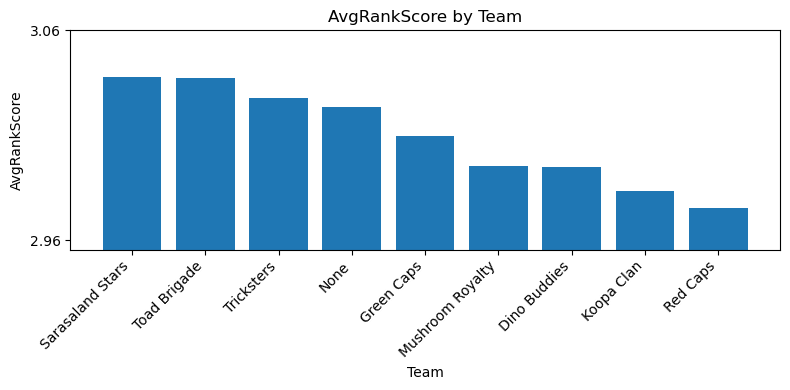

```python
# Better-scale AvgRankScore chart
metric_col = "AvgRankScore"
agg = (
    team_df.groupby("Team", as_index=False)[metric_col]
    .mean()
    .sort_values(metric_col, ascending=False)
)

plt.figure(figsize=(8,4))
plt.bar(agg["Team"], agg[metric_col])
plt.title("AvgRankScore by Team")
plt.xticks(rotation=45, ha="right")
plt.xlabel("Team")
plt.ylabel(metric_col)

# Narrow the y-axis range & tick step
ymin, ymax = agg[metric_col].min() - 0.02, agg[metric_col].max() + 0.02
plt.ylim(ymin, ymax)
plt.yticks(np.arange(round(ymin,2), round(ymax,2)+0.01, 0.1))

plt.tight_layout()
plt.show()
```

## Gold: 2) Player Performance

This section analyzes individual player results from the Gold layer. It displays each player’s performance metrics and visualizes the top performers to highlight differences in scoring or ranking outcomes.

```python
# ---- Safer label/score detection + plot ----
from pandas.api.types import is_string_dtype, is_categorical_dtype, is_numeric_dtype

# 1) pick a label column (prefer common name columns; else first string-like)
preferred_labels = ["Player Name", "Player", "Name", "GamerTag", "User", "Username"]
label_col = next((c for c in preferred_labels if c in pp_df.columns), None)
if label_col is None:
    string_like = [c for c in pp_df.columns if is_string_dtype(pp_df[c]) or is_categorical_dtype(pp_df[c])]
    label_col = string_like[0] if string_like else None

# if still nothing, create a simple index label so we can plot
if label_col is None:
    pp_df = pp_df.reset_index().rename(columns={"index":"Item"})
    label_col = "Item"

# 2) pick a numeric score column (not the index/label)
num_cols = [c for c in pp_df.columns if is_numeric_dtype(pp_df[c]) and c != label_col]
# prefer columns that sound like a score/points
score_pref = [c for c in num_cols if "point" in c.lower() or "score" in c.lower() or "rank" in c.lower()]
score_col = score_pref[0] if score_pref else (num_cols[0] if num_cols else None)

print("Label:", label_col)
print("Score:", score_col)

# 3) Top 10 table
top_players = pp_df.sort_values(score_col, ascending=False).head(10)
display(top_players[[label_col, score_col]])

# 4) Improved chart (tight scale + readable ticks)
import numpy as np
vals = top_players[score_col].astype(float).values
ymin, ymax = vals.min(), vals.max()
pad = (ymax - ymin) * 0.05 if ymax > ymin else 0.05
ymin2, ymax2 = ymin - pad, ymax + pad
```

```
Label: Player Name
Score: TotalTeamPoints
```

|  | Player Name | TotalTeamPoints |
| --- | --- | --- |
| 0 | Luigi | 172753 |
| 1 | Bowser Jr. | 170904 |
| 2 | Bowser | 165782 |
| 3 | Waluigi | 165295 |
| 4 | Mario | 163282 |
| 5 | Daisy | 163110 |
| 6 | Rosalina | 162711 |
| 7 | Toad | 161178 |
| 8 | Peach | 159581 |
| 9 | Wario | 157402 |

[figure not shown]

```python
# Replot with tight y-scale and fine ticks
vals = top_players[score_col].astype(float).values
ymin, ymax = vals.min(), vals.max()

# Add a small padding
pad = (ymax - ymin) * 0.05 if ymax > ymin else 0.05
ymin2, ymax2 = ymin - pad, ymax + pad

plt.figure(figsize=(8,4))
plt.bar(top_players[label_col].astype(str), top_players[score_col].astype(float))
plt.title(f"Top 10 by {score_col}")
plt.xticks(rotation=45, ha="right")
plt.xlabel(label_col); plt.ylabel(score_col)
plt.ylim(ymin2, ymax2)

# Set ~8 ticks across the range
import numpy as np
tick_step = max((ymax2 - ymin2) / 8, 0.1)
ticks = np.arange(ymin2, ymax2 + tick_step/2, tick_step)
plt.yticks(np.round(ticks, 2))

plt.tight_layout()
plt.show()
```

## Gold: 3) Power-Ups per Player

This section examines player power-up usage, showing the average number of power-ups used per player. A distribution chart illustrates differences in playstyle and resource utilization across characters.

```python
# ---- Gold: Power-Ups per Player ----
pu_path = GOLD_DIR / "gold_powerup_player.parquet"
pu_df = pd.read_parquet(pu_path)

# 1) Preview the first few rows
preview(pu_df, n=15)

# 2) Identify the column that counts power-ups
import numpy as np
power_cols = [c for c in pu_df.columns if "power" in c.lower() and np.issubdtype(pu_df[c].dtype, np.number)]
col = power_cols[0] if power_cols else pu_df.select_dtypes("number").columns[0]

print("Using column:", col)
```

|  | Player Name | RecordCount | AvgPowerUpsUsed |
| --- | --- | --- | --- |
| 0 | Rosalina | 3234 | 17.754484 |
| 1 | Toad | 3217 | 17.644078 |
| 2 | Bowser Jr. | 3241 | 17.525455 |
| 3 | Yoshi | 3304 | 17.486077 |
| 4 | Daisy | 3294 | 17.472981 |
| 5 | Bowser | 3268 | 17.407895 |
| 6 | Luigi | 3269 | 17.398287 |
| 7 | Toadette | 3290 | 17.384498 |
| 8 | Waluigi | 3321 | 17.364950 |
| 9 | Wario | 3114 | 17.359987 |
| 10 | Peach | 3230 | 17.309598 |
| 11 | Mario | 3178 | 17.192259 |

```
rows=12 | cols=3 | columns=['Player Name', 'RecordCount', 'AvgPowerUpsUsed']
Using column: AvgPowerUpsUsed
```

[figure not shown]

```python
# Better Power-Ups chart (sorted + zoomed scale)
col = "AvgPowerUpsUsed"

# Sort players by average power-ups
sorted_df = pu_df.sort_values(col, ascending=False)

plt.figure(figsize=(8,4))
plt.bar(sorted_df["Player Name"], sorted_df[col], color="skyblue", edgecolor="black")

# Tight y-axis for clearer differences
ymin, ymax = sorted_df[col].min(), sorted_df[col].max()
pad = (ymax - ymin) * 0.05
plt.ylim(ymin - pad, ymax + pad)
plt.yticks(np.arange(round(ymin,1)-0.1, round(ymax,1)+0.1, 0.1))

plt.title("Average Power-Ups Used per Player")
plt.xlabel("Player Name")
plt.ylabel("Avg Power-Ups Used")
plt.xticks(rotation=45, ha="right")
plt.tight_layout()
plt.show()
```

## Gold: 4) World Difficulty

This section shows the relative difficulty of each world, including the easiest and hardest based on the Gold layer output.

|  | World | AvgLivesLost |
| --- | --- | --- |
| 0 | Toad Town | 2.530942 |
| 1 | Mushroom Kingdom | 2.525834 |
| 2 | Donut Plains | 2.521640 |
| 3 | Yoshis Island | 2.496362 |
| 4 | Star World | 2.486879 |
| 5 | Koopa Kingdom | 2.485890 |

```
rows=6 | cols=2 | columns=['World', 'AvgLivesLost']
Hardest Worlds:
```

|  | World | AvgLivesLost |
| --- | --- | --- |
| 0 | Toad Town | 2.530942 |
| 1 | Mushroom Kingdom | 2.525834 |
| 2 | Donut Plains | 2.521640 |
| 3 | Yoshis Island | 2.496362 |
| 4 | Star World | 2.486879 |

```
Easiest Worlds:
```

|  | World | AvgLivesLost |
| --- | --- | --- |
| 5 | Koopa Kingdom | 2.485890 |
| 4 | Star World | 2.486879 |
| 3 | Yoshis Island | 2.496362 |
| 2 | Donut Plains | 2.521640 |
| 1 | Mushroom Kingdom | 2.525834 |

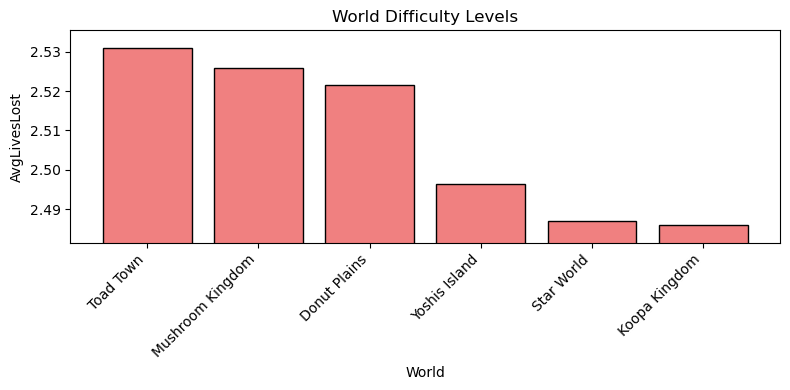

```python
# ---- Gold: World Difficulty ----
wd_path = GOLD_DIR / "gold_world_difficulty.parquet"
wd_df = pd.read_parquet(wd_path)

# 1) Preview the table
preview(wd_df, n=15)

# 2) Identify the difficulty column automatically
import numpy as np
diff_col = next((c for c in wd_df.columns if "difficulty" in c.lower()), wd_df.select_dtypes("number").columns[0])

# 3) Sort and display hardest and easiest worlds
hardest = wd_df.sort_values(diff_col, ascending=False).head(5)
easiest = wd_df.sort_values(diff_col, ascending=True).head(5)

print("Hardest Worlds:")
display(hardest)
print("Easiest Worlds:")
display(easiest)

# 4) Plot world difficulties
plt.figure(figsize=(8,4))
plt.bar(wd_df["World"], wd_df[diff_col], color="lightcoral", edgecolor="black")
plt.title("World Difficulty Levels")
plt.xlabel("World")
plt.ylabel(diff_col)
plt.xticks(rotation=45, ha="right")

# Tighten the y-axis for better visual separation
ymin, ymax = wd_df[diff_col].min(), wd_df[diff_col].max()
pad = (ymax - ymin) * 0.1
plt.ylim(ymin - pad, ymax + pad)

plt.tight_layout()
plt.show()
```

## Gold: 5) Risk Assessment

|  | Player Name | TotalLivesLost |
| --- | --- | --- |
| 0 | Yoshi | 8367 |
| 1 | Waluigi | 8349 |
| 2 | Toadette | 8338 |
| 3 | Daisy | 8214 |
| 4 | Peach | 8166 |
| 5 | Bowser Jr. | 8160 |
| 6 | Luigi | 8103 |
| 7 | Rosalina | 8092 |
| 8 | Toad | 8085 |
| 9 | Bowser | 8072 |
| 10 | Mario | 8000 |
| 11 | Wario | 7763 |

```
rows=12 | cols=2 | columns=['Player Name', 'TotalLivesLost']
Highest Risk:
```

|  | Player Name | TotalLivesLost |
| --- | --- | --- |
| 0 | Yoshi | 8367 |
| 1 | Waluigi | 8349 |
| 2 | Toadette | 8338 |
| 3 | Daisy | 8214 |
| 4 | Peach | 8166 |

```
Lowest Risk:
```

|  | Player Name | TotalLivesLost |
| --- | --- | --- |
| 11 | Wario | 7763 |
| 10 | Mario | 8000 |
| 9 | Bowser | 8072 |
| 8 | Toad | 8085 |
| 7 | Rosalina | 8092 |

[figure not shown]

```python
# ---- Gold: Risk Assessment ----
ra_path = GOLD_DIR / "gold_risk_assessment.parquet"
ra_df = pd.read_parquet(ra_path)

# 1) Preview the table
preview(ra_df, n=15)

# 2) Identify the risk column automatically
import numpy as np
risk_col = next((c for c in ra_df.columns if "risk" in c.lower()), ra_df.select_dtypes("number").columns[0])

# 3) Sort and display highest and lowest risk
highest = ra_df.sort_values(risk_col, ascending=False).head(5)
lowest = ra_df.sort_values(risk_col, ascending=True).head(5)

print("Highest Risk:")
display(highest)
print("Lowest Risk:")
display(lowest)

# 4) Detect a label column (world, player, or team)
label_candidates = [c for c in ra_df.columns if ra_df[c].dtype == 'string' or ra_df[c].dtype == 'object']
label_col = label_candidates[0] if label_candidates else ra_df.columns[0]

# 5) Plot risk values
plt.figure(figsize=(8,4))
plt.bar(ra_df[label_col], ra_df[risk_col], color="goldenrod", edgecolor="black")
plt.title(f"Risk Levels by {label_col}")
plt.xlabel(label_col)
plt.ylabel(risk_col)
plt.xticks(rotation=45, ha="right")

# Tighten the y-axis range
ymin, ymax = ra_df[risk_col].min(), ra_df[risk_col].max()
pad = (ymax - ymin) * 0.1
plt.ylim(ymin - pad, ymax + pad)

plt.tight_layout()
plt.show()
```

## Gold: 6) Vehicle Counts

This section summarizes how often each vehicle type appears in the Gold layer and visualizes the distribution to highlight the most and least common choices.

```python
# ---- Gold: Vehicle Counts ----
vc_path = GOLD_DIR / "gold_vehicle_counts.parquet"
vc_df = pd.read_parquet(vc_path)

# 1) Preview the table
preview(vc_df, n=15)

# 2) Identify label and count columns robustly
from pandas.api.types import is_string_dtype, is_numeric_dtype

# Label (vehicle/type)
label_candidates = [c for c in vc_df.columns if is_string_dtype(vc_df[c])]
prefer = [c for c in label_candidates if "vehicle" in c.lower() or "type" in c.lower()]
veh_col = prefer[0] if prefer else (label_candidates[0] if label_candidates else vc_df.columns[0])

# Count/metric
num_cols = [c for c in vc_df.columns if is_numeric_dtype(vc_df[c])]
cnt_pref = [c for c in num_cols if "count" in c.lower() or "total" in c.lower() or "num" in c.lower()]
cnt_col = cnt_pref[0] if cnt_pref else (num_cols[0] if num_cols else None)

print("Vehicle column:", veh_col)
print("Count column:", cnt_col)

# 3) Aggregate and sort ascending for horizontal bars
agg = (
    vc_df.groupby(veh_col, as_index=False)[cnt_col]
    .sum()
    .sort_values(cnt_col, ascending=True)
)
```

|  | Vehicle Type | Count |
| --- | --- | --- |
| 0 | Scooter | 5650 |
| 1 | Comet Bike | 5602 |
| 2 | Biddybuggy | 5571 |
| 3 | Pipe Frame | 5557 |
| 4 | Standard Kart | 5557 |
| 5 | Circuit Special | 5529 |
| 6 | Mach 8 | 5494 |

```
rows=7 | cols=2 | columns=['Vehicle Type', 'Count']
Vehicle column: Vehicle Type
Count column: Count
```

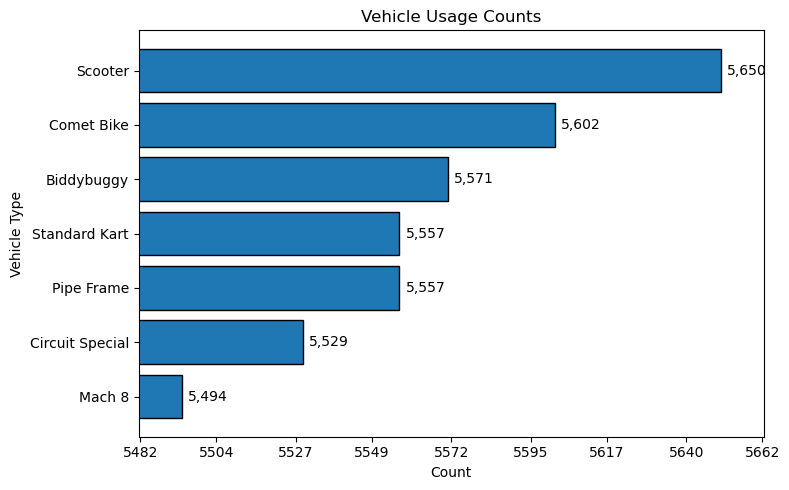

```python
# Zoom, finer ticks, and data labels for Vehicle Counts
vals = agg[cnt_col].astype(float).values
xmin, xmax = vals.min(), vals.max()

pad = (xmax - xmin) * 0.08 if xmax > xmin else 1.0
xmin2, xmax2 = max(0, xmin - pad), xmax + pad

import numpy as np
plt.figure(figsize=(8,5))
plt.barh(agg[veh_col].astype("string"), vals, edgecolor="black")

# Tight x-axis + fine ticks
plt.xlim(xmin2, xmax2)
tick_step = max((xmax2 - xmin2) / 8, 1)
ticks = np.arange(xmin2, xmax2 + tick_step/2, tick_step)
plt.xticks(np.round(ticks, 0))

plt.title("Vehicle Usage Counts")
plt.xlabel(cnt_col)
plt.ylabel(veh_col)

# Add value labels at end of bars
for y, v in enumerate(vals):
    plt.text(v + (xmax2 - xmin2)*0.01, y, f"{int(v):,}", va="center")

plt.tight_layout()
plt.show()
```

## Gold: 7) Top Player per Team

|  | Team | Player Name | TotalTeamPoints |
| --- | --- | --- | --- |
| 0 | Dino Buddies | Bowser | 21605 |
| 1 | Green Caps | Bowser Jr. | 21799 |
| 2 | Koopa Clan | Peach | 22100 |
| 3 | Mushroom Royalty | Wario | 23334 |
| 4 | None | Bowser | 12007 |
| 5 | Red Caps | Bowser | 21665 |
| 6 | Sarasaland Stars | Mario | 24166 |
| 7 | Toad Brigade | Peach | 22726 |
| 8 | Tricksters | Luigi | 20526 |

```
rows=9 | cols=3 | columns=['Team', 'Player Name', 'TotalTeamPoints']
Team column: Team
Player column: Player Name
Score column: TotalTeamPoints
```

|  | Team | Player Name | TotalTeamPoints |
| --- | --- | --- | --- |
| 6 | Sarasaland Stars | Mario | 24166 |
| 3 | Mushroom Royalty | Wario | 23334 |
| 7 | Toad Brigade | Peach | 22726 |
| 2 | Koopa Clan | Peach | 22100 |
| 1 | Green Caps | Bowser Jr. | 21799 |
| 5 | Red Caps | Bowser | 21665 |
| 0 | Dino Buddies | Bowser | 21605 |
| 8 | Tricksters | Luigi | 20526 |
| 4 | None | Bowser | 12007 |

[figure not shown]

```python
# ---- Gold: Top Player per Team ----
tpt_path = GOLD_DIR / "gold_top_player_per_team.parquet"
tpt_df = pd.read_parquet(tpt_path)

# 1) Preview the table
preview(tpt_df, n=30)

# 2) Identify columns robustly
from pandas.api.types import is_string_dtype, is_numeric_dtype

name_candidates = [c for c in tpt_df.columns if is_string_dtype(tpt_df[c]) and "player" in c.lower()]
team_candidates = [c for c in tpt_df.columns if is_string_dtype(tpt_df[c]) and "team" in c.lower()]
num_candidates  = [c for c in tpt_df.columns if is_numeric_dtype(tpt_df[c])]

player_col = name_candidates[0] if name_candidates else next((c for c in tpt_df.columns if is_string_dtype(tpt_df[c])), tpt_df.columns[0])
team_col   = team_candidates[0] if team_candidates else ( "Team" if "Team" in tpt_df.columns else tpt_df.columns[0] )
score_pref = [c for c in num_candidates if "point" in c.lower() or "score" in c.lower() or "rank" in c.lower()]
score_col  = score_pref[0] if score_pref else (num_candidates[0] if num_candidates else None)

print("Team column:", team_col)
print("Player column:", player_col)
print("Score column:", score_col)

# 3) Ensure one row per team (safety) and sort by score
agg = (tpt_df.groupby([team_col, player_col], as_index=False)[score_col]
             .max()
             .sort_values(score_col, ascending=False))

display(agg)

# 4) Bar chart of team scores with player name annotations
vals = agg[score_col].astype(float).values
ymin, ymax = vals.min(), vals.max()
pad = (ymax - ymin) * 0.08 if ymax > ymin else 0.5
ymin2, ymax2 = ymin - pad, ymax + pad

plt.figure(figsize=(8,4))
plt.bar(agg[team_col].astype(str), vals, edgecolor="black")
plt.title(f"Top Player per Team — {score_col}")
plt.xticks(rotation=45, ha="right")
plt.xlabel(team_col); plt.ylabel(score_col)
plt.ylim(ymin2, ymax2)

# annotate bars with player names
for x, (team, player, v) in enumerate(zip(agg[team_col].astype(str), agg[player_col].astype(str), vals)):
    plt.text(x, v + (ymax2 - ymin2)*0.02, player, ha="center", rotation=0)

plt.tight_layout()
plt.show()
```

## Gold: 8) World Completion

This section summarizes how fully each world is completed in the Gold layer and visualizes the highest and lowest completion levels. Completion data highlights which worlds players tend to finish most often versus those that remain incomplete.

|  | World | TotalLevels | AvgLevels |
| --- | --- | --- | --- |
| 0 | Donut Plains | 412298 | 62.831149 |
| 1 | Koopa Kingdom | 409121 | 62.748620 |
| 2 | Toad Town | 405980 | 62.496921 |
| 3 | Star World | 404138 | 62.386230 |
| 4 | Yoshis Island | 403170 | 62.419879 |
| 5 | Mushroom Kingdom | 398709 | 61.863305 |

```
rows=6 | cols=3 | columns=['World', 'TotalLevels', 'AvgLevels']
World column: World
Completion column: TotalLevels
Highest completion:
```

|  | World | TotalLevels | AvgLevels |
| --- | --- | --- | --- |
| 0 | Donut Plains | 412298 | 62.831149 |
| 1 | Koopa Kingdom | 409121 | 62.748620 |
| 2 | Toad Town | 405980 | 62.496921 |
| 3 | Star World | 404138 | 62.386230 |
| 4 | Yoshis Island | 403170 | 62.419879 |

```
Lowest completion:
```

|  | World | TotalLevels | AvgLevels |
| --- | --- | --- | --- |
| 5 | Mushroom Kingdom | 398709 | 61.863305 |
| 4 | Yoshis Island | 403170 | 62.419879 |
| 3 | Star World | 404138 | 62.386230 |
| 2 | Toad Town | 405980 | 62.496921 |
| 1 | Koopa Kingdom | 409121 | 62.748620 |

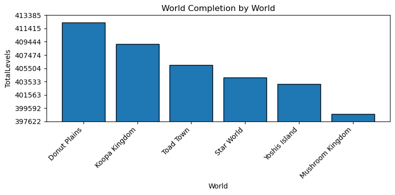

```python
# ---- Gold: World Completion ----
wc_path = GOLD_DIR / "gold_world_completion.parquet"
wc_df = pd.read_parquet(wc_path)

# 1) Preview the table
preview(wc_df, n=15)

# 2) Identify label (world) and completion metric
from pandas.api.types import is_string_dtype, is_numeric_dtype

world_col = next((c for c in wc_df.columns if is_string_dtype(wc_df[c]) and "world" in c.lower()), None)
if world_col is None:
    world_col = next((c for c in wc_df.columns if is_string_dtype(wc_df[c])), wc_df.columns[0])

num_cols = [c for c in wc_df.columns if is_numeric_dtype(wc_df[c])]
comp_pref = [c for c in num_cols if any(k in c.lower() for k in ["completion", "complete", "rate", "percent", "ratio"])]
comp_col = comp_pref[0] if comp_pref else (num_cols[0] if num_cols else None)

print("World column:", world_col)
print("Completion column:", comp_col)

# 3) Top/bottom worlds
top_worlds = wc_df.sort_values(comp_col, ascending=False).head(5)
bot_worlds = wc_df.sort_values(comp_col, ascending=True).head(5)
print("Highest completion:"); display(top_worlds)
print("Lowest completion:"); display(bot_worlds)

# 4) Plot (sorted) + tight y-scale
plot_df = wc_df.sort_values(comp_col, ascending=False)
vals = plot_df[comp_col].astype(float).values
ymin, ymax = vals.min(), vals.max()
pad = (ymax - ymin) * 0.08 if ymax > ymin else 0.05
ymin2, ymax2 = ymin - pad, ymax + pad

import numpy as np
plt.figure(figsize=(8,4))
plt.bar(plot_df[world_col].astype(str), vals, edgecolor="black")
plt.title(f"World Completion by {world_col}")
plt.xticks(rotation=45, ha="right")
plt.xlabel(world_col); plt.ylabel(comp_col)
plt.ylim(ymin2, ymax2)
tick_step = max((ymax2 - ymin2) / 8, 0.05)
ticks = np.arange(ymin2, ymax2 + tick_step/2, tick_step)
plt.yticks(np.round(ticks, 2))
plt.tight_layout()
plt.show()
```

## Gold: 9) Spending Analysis

This section examines how much each team or player spent in the Gold layer. It highlights spending behavior across groups and visualizes which entities spend the most and least resources overall.

```python
# ---- Gold: Spending Analysis ----
sa_path = GOLD_DIR / "gold_spending_analysis.parquet"
sa_df = pd.read_parquet(sa_path)

# 1) Preview the table
preview(sa_df, n=15)

# 2) Identify label and spending columns
from pandas.api.types import is_string_dtype, is_numeric_dtype

label_col = next((c for c in sa_df.columns if is_string_dtype(sa_df[c])), sa_df.columns[0])
num_cols = [c for c in sa_df.columns if is_numeric_dtype(sa_df[c])]
spend_pref = [c for c in num_cols if any(k in c.lower() for k in ["spend", "cost", "expense", "total"])]
spend_col = spend_pref[0] if spend_pref else (num_cols[0] if num_cols else None)

print("Label column:", label_col)
print("Spending column:", spend_col)

# 3) Sort and show top/bottom spenders
top_spenders = sa_df.sort_values(spend_col, ascending=False).head(5)
low_spenders = sa_df.sort_values(spend_col, ascending=True).head(5)
print("Top Spenders:"); display(top_spenders)
print("Lowest Spenders:"); display(low_spenders)

# 4) Plot spending (sorted, tight scale)
plot_df = sa_df.sort_values(spend_col, ascending=False)
vals = plot_df[spend_col].astype(float).values
ymin, ymax = vals.min(), vals.max()
pad = (ymax - ymin) * 0.08 if ymax > ymin else 0.05
ymin2, ymax2 = ymin - pad, ymax + pad

import numpy as np
```

|  | Team | TotalCoinsSpent |
| --- | --- | --- |
| 0 | Mushroom Royalty | 1179918 |
| 1 | Sarasaland Stars | 1164510 |
| 2 | Red Caps | 1145587 |
| 3 | Green Caps | 1140259 |
| 4 | Tricksters | 1137169 |
| 5 | Toad Brigade | 1130945 |
| 6 | Koopa Clan | 1109867 |
| 7 | Dino Buddies | 1102832 |
| 8 | None | 611044 |

```
rows=9 | cols=2 | columns=['Team', 'TotalCoinsSpent']
Label column: Team
Spending column: TotalCoinsSpent
Top Spenders:
```

|  | Team | TotalCoinsSpent |
| --- | --- | --- |
| 0 | Mushroom Royalty | 1179918 |
| 1 | Sarasaland Stars | 1164510 |
| 2 | Red Caps | 1145587 |
| 3 | Green Caps | 1140259 |
| 4 | Tricksters | 1137169 |

```
Lowest Spenders:
```

|  | Team | TotalCoinsSpent |
| --- | --- | --- |
| 8 | None | 611044 |
| 7 | Dino Buddies | 1102832 |
| 6 | Koopa Clan | 1109867 |
| 5 | Toad Brigade | 1130945 |
| 4 | Tricksters | 1137169 |

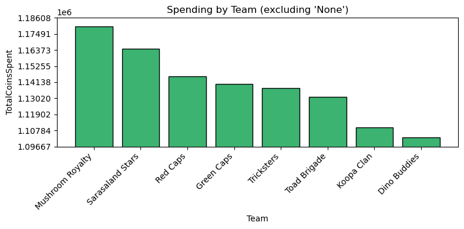

```python
# ---- Filter out "None" or missing teams before plotting ----
filtered_df = sa_df[
    sa_df[label_col].notna() &
    (sa_df[label_col].str.lower() != "none")
]

# Re-sort after filtering
plot_df = filtered_df.sort_values(spend_col, ascending=False)

# 4) Plot spending (sorted, tight scale)
vals = plot_df[spend_col].astype(float).values
ymin, ymax = vals.min(), vals.max()
pad = (ymax - ymin) * 0.08 if ymax > ymin else 0.05
ymin2, ymax2 = ymin - pad, ymax + pad

plt.figure(figsize=(8,4))
plt.bar(plot_df[label_col].astype(str), vals, edgecolor="black", color="mediumseagreen")
plt.title(f"Spending by {label_col} (excluding 'None')")
plt.xticks(rotation=45, ha="right")
plt.xlabel(label_col)
plt.ylabel(spend_col)
plt.ylim(ymin2, ymax2)

# Finer ticks
import numpy as np
tick_step = max((ymax2 - ymin2) / 8, 0.05)
ticks = np.arange(ymin2, ymax2 + tick_step/2, tick_step)
plt.yticks(np.round(ticks, 2))

plt.tight_layout()
plt.show()
```

## Gold: 10) Hits by Team

This section analyzes how often each team was hit by enemies in the Gold layer. It compares total and average hits across teams to identify which teams faced the most in-game adversity.

|  | Team | TotalHits | AvgHits |
| --- | --- | --- | --- |
| 0 | Sarasaland Stars | 23416 | 5.062919 |
| 1 | Mushroom Royalty | 23107 | 4.958584 |
| 2 | Toad Brigade | 22887 | 4.950681 |
| 3 | Red Caps | 22641 | 4.942371 |
| 4 | Tricksters | 22630 | 4.972534 |
| 5 | Koopa Clan | 22527 | 5.008226 |
| 6 | Green Caps | 22389 | 4.941293 |
| 7 | Dino Buddies | 22366 | 5.009183 |
| 8 | None | 12187 | 5.023495 |

```
rows=9 | cols=3 | columns=['Team', 'TotalHits', 'AvgHits']
Team column: Team
Hit column: TotalHits
Most hits received:
```

|  | Team | TotalHits | AvgHits |
| --- | --- | --- | --- |
| 0 | Sarasaland Stars | 23416 | 5.062919 |
| 1 | Mushroom Royalty | 23107 | 4.958584 |
| 2 | Toad Brigade | 22887 | 4.950681 |
| 3 | Red Caps | 22641 | 4.942371 |
| 4 | Tricksters | 22630 | 4.972534 |

```
Fewest hits received:
```

|  | Team | TotalHits | AvgHits |
| --- | --- | --- | --- |
| 7 | Dino Buddies | 22366 | 5.009183 |
| 6 | Green Caps | 22389 | 4.941293 |
| 5 | Koopa Clan | 22527 | 5.008226 |
| 4 | Tricksters | 22630 | 4.972534 |
| 3 | Red Caps | 22641 | 4.942371 |

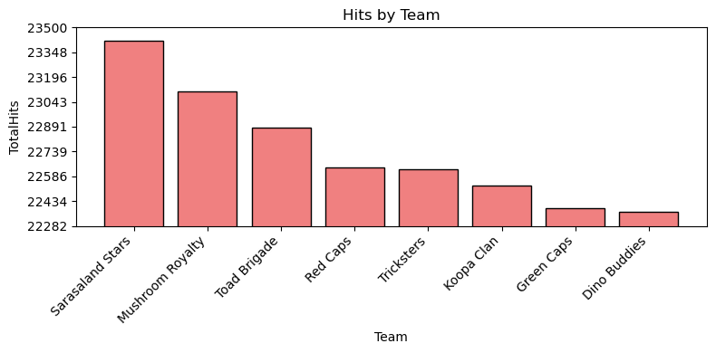

```python
# ---- Gold: Hits by Team ----
ht_path = GOLD_DIR / "gold_hits_team.parquet"
ht_df = pd.read_parquet(ht_path)

# 1) Preview the table
preview(ht_df, n=15)

# 2) Identify label (team) and hit columns
from pandas.api.types import is_string_dtype, is_numeric_dtype

team_col = next((c for c in ht_df.columns if is_string_dtype(ht_df[c]) and "team" in c.lower()), None)
if team_col is None:
    team_col = next((c for c in ht_df.columns if is_string_dtype(ht_df[c])), ht_df.columns[0])

num_cols = [c for c in ht_df.columns if is_numeric_dtype(ht_df[c])]
hit_pref = [c for c in num_cols if any(k in c.lower() for k in ["hit", "damage", "times", "count"])]
hit_col = hit_pref[0] if hit_pref else (num_cols[0] if num_cols else None)

print("Team column:", team_col)
print("Hit column:", hit_col)

# 3) Remove 'None' or missing teams for cleaner comparison
filtered_df = ht_df[
    ht_df[team_col].notna() &
    (ht_df[team_col].str.lower() != "none")
]

# 4) Sort and show top/bottom teams
top_hit = filtered_df.sort_values(hit_col, ascending=False).head(5)
low_hit = filtered_df.sort_values(hit_col, ascending=True).head(5)
print("Most hits received:"); display(top_hit)
print("Fewest hits received:"); display(low_hit)

# 5) Plot hits per team (sorted + tight scale)
plot_df = filtered_df.sort_values(hit_col, ascending=False)
vals = plot_df[hit_col].astype(float).values
ymin, ymax = vals.min(), vals.max()
pad = (ymax - ymin) * 0.08 if ymax > ymin else 0.05
ymin2, ymax2 = ymin - pad, ymax + pad

import numpy as np
plt.figure(figsize=(8,4))
plt.bar(plot_df[team_col].astype(str), vals, edgecolor="black", color="lightcoral")
plt.title(f"Hits by {team_col}")
plt.xticks(rotation=45, ha="right")
plt.xlabel(team_col); plt.ylabel(hit_col)
plt.ylim(ymin2, ymax2)
tick_step = max((ymax2 - ymin2) / 8, 0.05)
ticks = np.arange(ymin2, ymax2 + tick_step/2, tick_step)
plt.yticks(np.round(ticks, 2))
plt.tight_layout()
plt.show()
```

# Summary and Conclusions

This notebook presents the full Gold layer of the IS 640 ETL Project.  
Each dataset was cleaned, aggregated, and visualized following the Medallion Architecture approach.

Key insights include:

- **Team Summary**: Highlights overall performance and spending by team.
- **Player Performance**: Identifies top players and their contribution to team success.
- **Power-Ups and Risk**: Reveals differences in player strategy and risk exposure.
- **World-Level Analyses**: Show which environments are hardest to complete or cause the most losses.
- **Vehicle and Spending Metrics**: Illustrate variation in player choices and resource use.

Together, these reports demonstrate an end-to-end ETL pipeline that transforms raw game data into actionable analytics and visual insights.